# HW 03

## 3 - COVID survey - reconstruct with 10th–90th percentiles

```r
# ─────────────────────────────────────────────────────────
# Load CSV  &  Clean raw data
# ─────────────────────────────────────────────────────────
covid_survey <- read_csv("data/covid-survey.csv", skip = 1)
# Confirm the shape
dim(covid_survey)
```

```
[1] 1121   14
```

```r
# drop rows where EVERYTHING except response_id is NA
covid_survey <- covid_survey %>%
  filter(!if_all(-response_id, is.na))

# Confirm the shape again
dim(covid_survey)
```

```
[1] 1111   14
```

```r
# recode explanatory variables
covid_survey <- covid_survey %>%
  mutate(
    exp_already_vax = recode(exp_already_vax, `0` = "No", `1` = "Yes"),
    exp_flu_vax = recode(exp_flu_vax, `0` = "No", `1` = "Yes"),
    exp_profession = recode(exp_profession, `0` = "Medical", `1` = "Nursing"),
    exp_gender = recode(exp_gender, `0` = "Male", `1` = "Female", `3` = "Non-binary third gender", `4` = "Prefer not to say"),
    exp_race = recode(exp_race, `1` = "American Indian / Alaskan Native", `2` = "Asian", `3` = "Black / African American", `4` = "Native Hawaiian / Other Pacific Islander", `5` = "White"),
    exp_ethnicity = recode(exp_ethnicity, `1` = "Hispanic / Latino", `2` = "Non-Hispanic/Non-Latino"),
    exp_age_bin = recode(exp_age_bin, `0` = "<20", `20` = "21-25", `25` = "26-30", `30` = ">30")
  )

dim(covid_survey)
```

```
[1] 1111   14
```

```r
# ─────────────────────────────────────────────────────────
# Pivot to long & summarise (mean, 10th, 90th)
# ─────────────────────────────────────────────────────────
covid_survey_longer <- covid_survey %>%
  pivot_longer(
    cols = starts_with("exp_"),
    names_to = "explanatory",
    values_to = "explanatory_value"
  ) %>%
  filter(!is.na(explanatory_value)) %>%
  pivot_longer(
    cols = starts_with("resp_"),
    names_to = "response",
    values_to = "response_value"
  )

covid_survey_longer
```

```
# A tibble: 43,428 × 5
   response_id explanatory    explanatory_value response          response_value
         <dbl> <chr>          <chr>             <chr>                      <dbl>
 1           1 exp_profession Nursing           resp_safety                    5
 2           1 exp_profession Nursing           resp_confidence_…              2
 3           1 exp_profession Nursing           resp_concern_saf…              2
 4           1 exp_profession Nursing           resp_feel_safe_a…              1
 5           1 exp_profession Nursing           resp_will_recomm…              1
 6           1 exp_profession Nursing           resp_trust_info                1
 7           1 exp_flu_vax    Yes               resp_safety                    5
 8           1 exp_flu_vax    Yes               resp_confidence_…              2
 9           1 exp_flu_vax    Yes               resp_concern_saf…              2
10           1 exp_flu_vax    Yes               resp_feel_safe_a…              1
# ℹ 43,418 more rows
```

```r
covid_survey_summary_stats_by_group <- covid_survey_longer %>%
  group_by(explanatory, explanatory_value, response) %>%
  summarise(
    mean = mean(response_value, na.rm = TRUE),
    low = quantile(response_value, 0.10, na.rm = TRUE),
    high = quantile(response_value, 0.90, na.rm = TRUE),
    .groups = "drop"
  )

covid_survey_summary_stats_by_group
```

```
# A tibble: 126 × 6
   explanatory explanatory_value response                 mean   low  high
   <chr>       <chr>             <chr>                   <dbl> <dbl> <dbl>
 1 exp_age_bin 21-25             resp_concern_safety      3.32     2     5
 2 exp_age_bin 21-25             resp_confidence_science  1.31     1     2
 3 exp_age_bin 21-25             resp_feel_safe_at_work   1.20     1     2
 4 exp_age_bin 21-25             resp_safety              1.95     1     5
 5 exp_age_bin 21-25             resp_trust_info          1.29     1     2
 6 exp_age_bin 21-25             resp_will_recommend      1.09     1     1
 7 exp_age_bin 26-30             resp_concern_safety      3.35     1     5
 8 exp_age_bin 26-30             resp_confidence_science  1.40     1     2
 9 exp_age_bin 26-30             resp_feel_safe_at_work   1.29     1     2
10 exp_age_bin 26-30             resp_safety              2.16     1     5
# ℹ 116 more rows
```

```r
covid_survey_summary_stats_all <- covid_survey_longer %>%
  group_by(response) %>%
  summarise(
    mean = mean(response_value, na.rm = TRUE),
    low = quantile(response_value, 0.10, na.rm = TRUE),
    high = quantile(response_value, 0.90, na.rm = TRUE),
    .groups = "drop"
  ) %>%
  mutate(
    explanatory = "All",
    explanatory_value = ""
  )

covid_survey_summary_stats_all
```

```
# A tibble: 6 × 6
  response                 mean   low  high explanatory explanatory_value
  <chr>                   <dbl> <dbl> <dbl> <chr>       <chr>
1 resp_concern_safety      3.28     1     5 All         ""
2 resp_confidence_science  1.43     1     2 All         ""
3 resp_feel_safe_at_work   1.36     1     2 All         ""
4 resp_safety              2.03     1     5 All         ""
5 resp_trust_info          1.40     1     2 All         ""
6 resp_will_recommend      1.21     1     2 All         ""
```

```r
covid_survey_summary_stats <- bind_rows(
  covid_survey_summary_stats_all,
  covid_survey_summary_stats_by_group
)

covid_survey_summary_stats
```

```
# A tibble: 132 × 6
   response                 mean   low  high explanatory explanatory_value
   <chr>                   <dbl> <dbl> <dbl> <chr>       <chr>
 1 resp_concern_safety      3.28     1     5 All         ""
 2 resp_confidence_science  1.43     1     2 All         ""
 3 resp_feel_safe_at_work   1.36     1     2 All         ""
 4 resp_safety              2.03     1     5 All         ""
 5 resp_trust_info          1.40     1     2 All         ""
 6 resp_will_recommend      1.21     1     2 All         ""
 7 resp_concern_safety      3.32     2     5 exp_age_bin "21-25"
 8 resp_confidence_science  1.31     1     2 exp_age_bin "21-25"
 9 resp_feel_safe_at_work   1.20     1     2 exp_age_bin "21-25"
10 resp_safety              1.95     1     5 exp_age_bin "21-25"
# ℹ 122 more rows
```

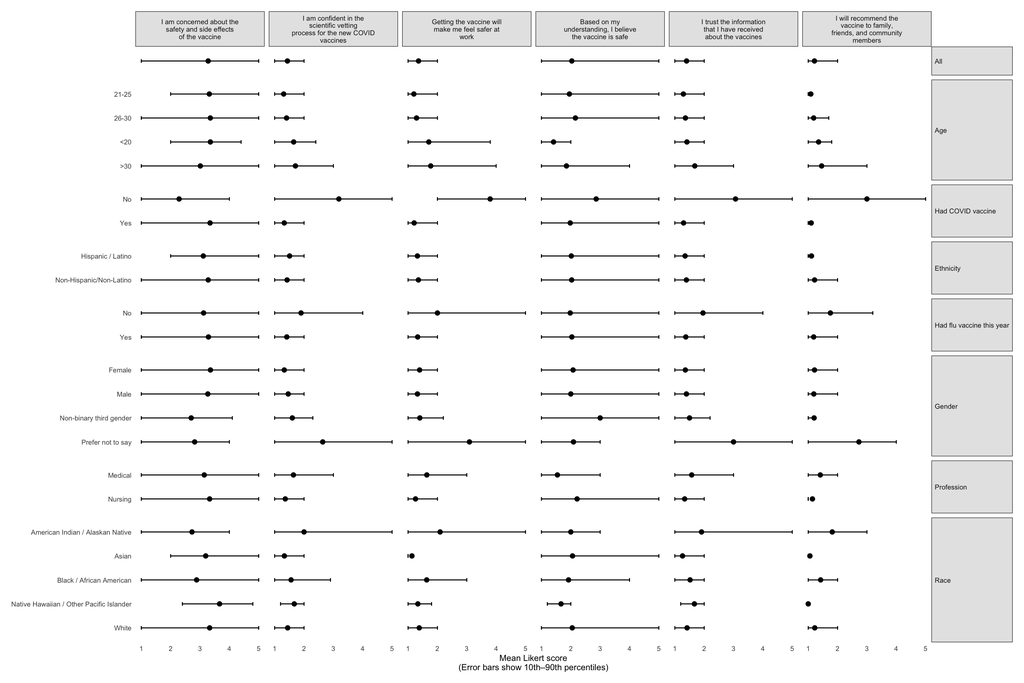

```r
# ─────────────────────────────────────────────────────────
# Facet-strip label vectors
# ─────────────────────────────────────────────────────────
response_labels <- c(
  resp_safety = "Based on my understanding,\nI believe the vaccine is safe",
  resp_confidence_science = "I am confident in the\nscientific vetting process\nfor the new COVID vaccines",
  resp_feel_safe_at_work = "Getting the vaccine\nwill make me feel safer at work",
  resp_will_recommend = "I will recommend the vaccine\nto family, friends,\nand community members",
  resp_trust_info = "I trust the information that\nI have received about the vaccines",
  resp_concern_safety = "I am concerned about the\nsafety and side effects\nof the vaccine"
)

explanatory_labels <- c(
  exp_age_bin = "Age",
  exp_gender = "Gender",
  exp_race = "Race",
  exp_ethnicity = "Ethnicity",
  exp_profession = "Profession",
  exp_already_vax = "Had COVID vaccine",
  exp_flu_vax = "Had flu vaccine this year",
  All = "All"
)

options(repr.plot.width  = 18,
        repr.plot.height = 15)

covid_survey_summary_stats <- covid_survey_summary_stats %>%
  group_by(explanatory) %>%
  mutate(explanatory_value = fct_rev(fct_inorder(explanatory_value))) %>%
  ungroup()

resp_lab_wrapped <- setNames(
  str_wrap(unname(response_labels), width = 25),
  names(response_labels)
)

# ─────────────────────────────────────────────────────────
# Final faceted plot
# ─────────────────────────────────────────────────────────
ggplot(covid_survey_summary_stats,
       aes(x = mean, y = explanatory_value)) +
  geom_point(size = 2) +
  geom_errorbarh(aes(xmin = low, xmax = high), height = .15) +
  facet_grid(
    explanatory ~ response,
    scales  = "free_y",
    space   = "free_y",
    labeller = labeller(
      response    = resp_lab_wrapped,
      explanatory = explanatory_labels
    )
  ) +
  scale_x_continuous(breaks = 1:5) +
  coord_cartesian(xlim = c(1, 5)) +
  theme_minimal(base_size = 9) +
  theme(
    strip.background   = element_rect(fill = "gray90", colour = "black"),
    strip.text.y       = element_text(angle = 0, hjust = 0),
    axis.title.y       = element_blank(),
    axis.title.x = element_text(colour = "black"),
    plot.margin        = margin(12, 12, 12, 12),
    panel.grid.major   = element_blank(),
    panel.grid.minor   = element_blank()
  ) +
  labs(
    x = "Mean Likert score\n(Error bars show 10th–90th percentiles)"
  )
```

## 4 - COVID survey - re-reconstruct with 25th-75th percentile

```r
#| label: COVID survey - reconstruct

# ─────────────────────────────────────────────────────────
# Load CSV  &  Clean raw data
# ─────────────────────────────────────────────────────────
covid_survey <- read_csv("data/covid-survey.csv", skip = 1)
# Confirm the shape
dim(covid_survey)
```

```
[1] 1121   14
```

```r
# drop rows where EVERYTHING except response_id is NA
covid_survey <- covid_survey %>%
  filter(!if_all(-response_id, is.na))

# Confirm the shape again
dim(covid_survey)
```

```
[1] 1111   14
```

```r
# recode explanatory variables
covid_survey <- covid_survey %>%
  mutate(
    exp_already_vax = recode(exp_already_vax, `0` = "No", `1` = "Yes"),
    exp_flu_vax = recode(exp_flu_vax, `0` = "No", `1` = "Yes"),
    exp_profession = recode(exp_profession, `0` = "Medical", `1` = "Nursing"),
    exp_gender = recode(exp_gender, `0` = "Male", `1` = "Female", `3` = "Non-binary third gender", `4` = "Prefer not to say"),
    exp_race = recode(exp_race, `1` = "American Indian / Alaskan Native", `2` = "Asian", `3` = "Black / African American", `4` = "Native Hawaiian / Other Pacific Islander", `5` = "White"),
    exp_ethnicity = recode(exp_ethnicity, `1` = "Hispanic / Latino", `2` = "Non-Hispanic/Non-Latino"),
    exp_age_bin = recode(exp_age_bin, `0` = "<20", `20` = "21-25", `25` = "26-30", `30` = ">30")
  )

dim(covid_survey)
```

```
[1] 1111   14
```

```r
# ─────────────────────────────────────────────────────────
# Pivot to long & summarise (mean, 10th, 90th)
# ─────────────────────────────────────────────────────────
covid_survey_longer <- covid_survey %>%
  pivot_longer(
    cols = starts_with("exp_"),
    names_to = "explanatory",
    values_to = "explanatory_value"
  ) %>%
  filter(!is.na(explanatory_value)) %>%
  pivot_longer(
    cols = starts_with("resp_"),
    names_to = "response",
    values_to = "response_value"
  )

covid_survey_longer
```

```
# A tibble: 43,428 × 5
   response_id explanatory    explanatory_value response          response_value
         <dbl> <chr>          <chr>             <chr>                      <dbl>
 1           1 exp_profession Nursing           resp_safety                    5
 2           1 exp_profession Nursing           resp_confidence_…              2
 3           1 exp_profession Nursing           resp_concern_saf…              2
 4           1 exp_profession Nursing           resp_feel_safe_a…              1
 5           1 exp_profession Nursing           resp_will_recomm…              1
 6           1 exp_profession Nursing           resp_trust_info                1
 7           1 exp_flu_vax    Yes               resp_safety                    5
 8           1 exp_flu_vax    Yes               resp_confidence_…              2
 9           1 exp_flu_vax    Yes               resp_concern_saf…              2
10           1 exp_flu_vax    Yes               resp_feel_safe_a…              1
# ℹ 43,418 more rows
```

```r
# Changes according to
covid_survey_summary_stats_by_group <- covid_survey_longer %>%
  group_by(explanatory, explanatory_value, response) %>%
  summarise(
    mean = mean(response_value, na.rm = TRUE),
    low = quantile(response_value, 0.25, na.rm = TRUE),
    high = quantile(response_value, 0.75, na.rm = TRUE),
    .groups = "drop"
  )

covid_survey_summary_stats_by_group
```

```
# A tibble: 126 × 6
   explanatory explanatory_value response                 mean   low  high
   <chr>       <chr>             <chr>                   <dbl> <dbl> <dbl>
 1 exp_age_bin 21-25             resp_concern_safety      3.32     2   4
 2 exp_age_bin 21-25             resp_confidence_science  1.31     1   2
 3 exp_age_bin 21-25             resp_feel_safe_at_work   1.20     1   1
 4 exp_age_bin 21-25             resp_safety              1.95     1   2
 5 exp_age_bin 21-25             resp_trust_info          1.29     1   1
 6 exp_age_bin 21-25             resp_will_recommend      1.09     1   1
 7 exp_age_bin 26-30             resp_concern_safety      3.35     2   4.5
 8 exp_age_bin 26-30             resp_confidence_science  1.40     1   2
 9 exp_age_bin 26-30             resp_feel_safe_at_work   1.29     1   1
10 exp_age_bin 26-30             resp_safety              2.16     1   4
# ℹ 116 more rows
```

```r
covid_survey_summary_stats_all <- covid_survey_longer %>%
  group_by(response) %>%
  summarise(
    mean = mean(response_value, na.rm = TRUE),
    low = quantile(response_value, 0.25, na.rm = TRUE),
    high = quantile(response_value, 0.75, na.rm = TRUE),
    .groups = "drop"
  ) %>%
  mutate(
    explanatory = "All",
    explanatory_value = ""
  )

covid_survey_summary_stats_all
```

```
# A tibble: 6 × 6
  response                 mean   low  high explanatory explanatory_value
  <chr>                   <dbl> <dbl> <dbl> <chr>       <chr>
1 resp_concern_safety      3.28     2     4 All         ""
2 resp_confidence_science  1.43     1     2 All         ""
3 resp_feel_safe_at_work   1.36     1     1 All         ""
4 resp_safety              2.03     1     3 All         ""
5 resp_trust_info          1.40     1     2 All         ""
6 resp_will_recommend      1.21     1     1 All         ""
```

```r
covid_survey_summary_stats <- bind_rows(
  covid_survey_summary_stats_all,
  covid_survey_summary_stats_by_group
)

covid_survey_summary_stats
```

```
# A tibble: 132 × 6
   response                 mean   low  high explanatory explanatory_value
   <chr>                   <dbl> <dbl> <dbl> <chr>       <chr>
 1 resp_concern_safety      3.28     2     4 All         ""
 2 resp_confidence_science  1.43     1     2 All         ""
 3 resp_feel_safe_at_work   1.36     1     1 All         ""
 4 resp_safety              2.03     1     3 All         ""
 5 resp_trust_info          1.40     1     2 All         ""
 6 resp_will_recommend      1.21     1     1 All         ""
 7 resp_concern_safety      3.32     2     4 exp_age_bin "21-25"
 8 resp_confidence_science  1.31     1     2 exp_age_bin "21-25"
 9 resp_feel_safe_at_work   1.20     1     1 exp_age_bin "21-25"
10 resp_safety              1.95     1     2 exp_age_bin "21-25"
# ℹ 122 more rows
```

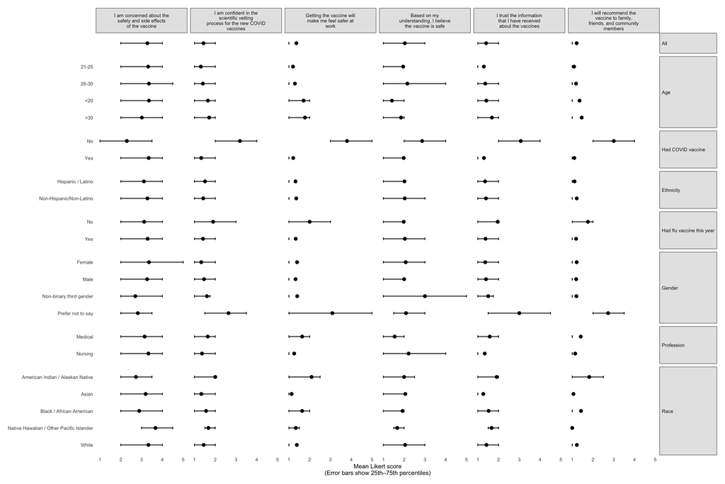

```r
# ─────────────────────────────────────────────────────────
# Facet-strip label vectors
# ─────────────────────────────────────────────────────────
response_labels <- c(
  resp_safety = "Based on my understanding,\nI believe the vaccine is safe",
  resp_confidence_science = "I am confident in the\nscientific vetting process\nfor the new COVID vaccines",
  resp_feel_safe_at_work = "Getting the vaccine\nwill make me feel safer at work",
  resp_will_recommend = "I will recommend the vaccine\nto family, friends,\nand community members",
  resp_trust_info = "I trust the information that\nI have received about the vaccines",
  resp_concern_safety = "I am concerned about the\nsafety and side effects\nof the vaccine"
)

explanatory_labels <- c(
  exp_age_bin = "Age",
  exp_gender = "Gender",
  exp_race = "Race",
  exp_ethnicity = "Ethnicity",
  exp_profession = "Profession",
  exp_already_vax = "Had COVID vaccine",
  exp_flu_vax = "Had flu vaccine this year",
  All = "All"
)

options(repr.plot.width  = 18,
        repr.plot.height = 15)

covid_survey_summary_stats <- covid_survey_summary_stats %>%
  group_by(explanatory) %>%
  mutate(explanatory_value = fct_rev(fct_inorder(explanatory_value))) %>%
  ungroup()

resp_lab_wrapped <- setNames(
  str_wrap(unname(response_labels), width = 25),
  names(response_labels)
)

# ─────────────────────────────────────────────────────────
# Final faceted plot
# ─────────────────────────────────────────────────────────
ggplot(covid_survey_summary_stats,
       aes(x = mean, y = explanatory_value)) +
  geom_point(size = 2) +
  geom_errorbarh(aes(xmin = low, xmax = high), height = .15) +
  facet_grid(
    explanatory ~ response,
    scales  = "free_y",
    space   = "free_y",
    labeller = labeller(
      response    = resp_lab_wrapped,
      explanatory = explanatory_labels
    )
  ) +
  scale_x_continuous(breaks = 1:5) +
  coord_cartesian(xlim = c(1, 5)) +
  theme_minimal(base_size = 9) +
  theme(
    strip.background   = element_rect(fill = "gray90", colour = "black"),
    strip.text.y       = element_text(angle = 0, hjust = 0),
    axis.title.y       = element_blank(),
    axis.title.x = element_text(colour = "black"),
    plot.margin        = margin(12, 12, 12, 12),
    panel.grid.major   = element_blank(),
    panel.grid.minor   = element_blank()
  ) +
  labs(
    x = "Mean Likert score\n(Error bars show 25th–75th percentiles)"
  )
```

Using the 25th–75th percentile range instead of the 10th–90th makes the plot more focused on the core responses, reducing the influence of outlines. This results in shorter error bars, making differences between groups appear more distinct and easier to compare. While the overall trends and conclusions remain consistent with the 10th–90th version, the revised plot provides a clearer view of the central tendency and typical variability in responses. It helps emphasize where most respondents fall, rather than highlighting the full range of opinions.

## 5 - COVID survey - another view

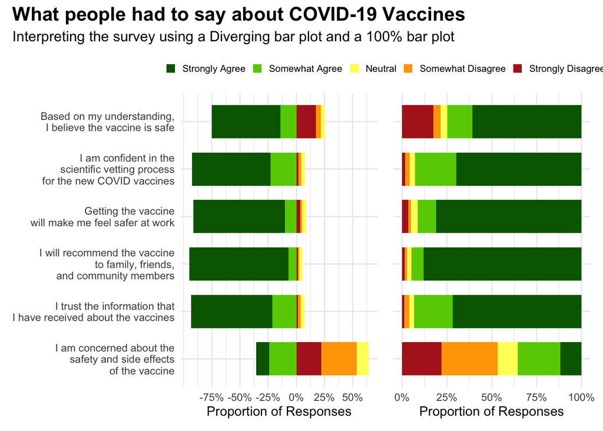

```r
likert_levels <- c("Strongly Agree", "Somewhat Agree", "Neutral", "Somewhat Disagree", "Strongly Disagree")
likert_colors <- c(
  "Strongly Agree" = "#006400",
  "Somewhat Agree" = "#66CD00",
  "Neutral" = "#FFFF66",
  "Somewhat Disagree" = "#FFA500",
  "Strongly Disagree" = "#B22222"
)

# Define descriptive question labels
response_labels <- c(
  resp_safety = "Based on my understanding,\nI believe the vaccine is safe",
  resp_confidence_science = "I am confident in the\nscientific vetting process\nfor the new COVID vaccines",
  resp_feel_safe_at_work = "Getting the vaccine\nwill make me feel safer at work",
  resp_will_recommend = "I will recommend the vaccine\nto family, friends,\nand community members",
  resp_trust_info = "I trust the information that\nI have received about the vaccines",
  resp_concern_safety = "I am concerned about the\nsafety and side effects\nof the vaccine"
)

# Prepare and summarize data
likert_summary <- covid_survey %>%
  pivot_longer(cols = starts_with("resp_"), names_to = "question", values_to = "response_value") %>%
  filter(!is.na(response_value)) %>%
  mutate(
    response_label = factor(response_value, levels = 1:5, labels = likert_levels),
    question = recode(question, !!!response_labels),
    question = factor(question, levels = response_labels)
  ) %>%
  count(question, response_label, name = "n") %>%
  group_by(question) %>%
  mutate(pct = n / sum(n)) %>%
  ungroup()

# Create diverging version of the data
likert_diverging <- likert_summary %>%
  mutate(pct = if_else(response_label %in% likert_levels[1:2], -pct, pct))

# Diverging bar plot
diverging_plot <- ggplot(likert_diverging, aes(x = pct, y = fct_rev(question), fill = response_label)) +
  geom_col(width = 0.7) +
  scale_x_continuous(
  breaks = seq(-0.75, 0.75, by = 0.25),
  labels = scales::percent_format(accuracy = 1)
  ) +
  scale_fill_manual(values = likert_colors) +
  labs(x = "Proportion of Responses", y = NULL) +
  theme_minimal() +
  theme(
    legend.position = "top",
    legend.text = element_text(size = 8),
    legend.title = element_blank(),
    legend.key.width = unit(0.3, "cm"),
    legend.key.height = unit(0.3, "cm"),
    legend.spacing.x = unit(0.3, "cm"),
    plot.margin = margin(5, 5, 5, 5)
  )

# 100% stacked bar plot
stacked_plot <- ggplot(likert_summary, aes(x = fct_rev(question), y = pct, fill = response_label)) +
  geom_col(position = "fill", width = 0.7) +
  coord_flip() +
  scale_y_continuous(labels = scales::percent_format(accuracy = 1)) +
  scale_fill_manual(values = likert_colors) +
  labs(x = NULL, y = "Proportion of Responses") +
  theme_minimal() +
  theme(
    axis.text.y = element_blank(),
    axis.ticks.y = element_blank(),
    axis.title.y = element_blank(),
    legend.position = "none",
    plot.margin = margin(5, 5, 5, 5)
  )

# Combine plots with shared legend
(diverging_plot + stacked_plot) +
  plot_layout(ncol = 2, widths = c(1.3, 1.3), guides = "collect") +
  plot_annotation(
    title = "What people had to say about COVID-19 Vaccines",
    subtitle = "Interpreting the survey using a Diverging bar plot and a 100% bar plot",
    theme = theme(plot.title = element_text(face = "bold", size = 16),
                  plot.subtitle = element_text(size = 12),
                  legend.position = "top")
  )
```

1. A diverging bar chart visualizing responses to six COVID-19 vaccine-related survey questions. Each question appears along the y-axis, and horizontal bars diverge left for positive sentiments and right for negative sentiments. Green shades represent agreement, yellow indicates neutrality, and red/orange shades represent disagreement. Most responses cluster toward the agreement side, especially for questions about vaccine safety, confidence in science, and recommendations to others.
2. A 100% stacked bar chart presenting the same six survey questions, with each bar representing the full distribution of responses. Green segments dominate most bars, especially for questions related to safety, trust, and recommendation, while disagreement is most notable in the question regarding concern about side effects.
3. The diverging bar chart emphasizes polarity—how far responses deviate from neutrality—making it easier to see which questions received strong agreement or disagreement. In contrast, the 100% bar chart emphasizes the distribution of responses within each question, making it ideal for comparing proportions across questions on the same scale.